# Week 11/12 Assignment

Nabila Hossain, Angus Huang

November 11, 2015

**For this assignment, we choose the [Movie Review Data](http://www.cs.cornell.edu/people/pabo/movie-review-data/) http://www.cs.cornell.edu/people/pabo/movie-review-data/ from Cornell University. We choose the sentiment polarity dataset: “polarity dataset v2.0,” which was introduced in Pang/Lee ACL in 2004. This dataset contains 1000 positive processed reviews and 1000 negative processed reviews.Classification of movie reivews are based on explicit numerical or star rating. Three and a half stars or more are considered positive in a five star rating system. With a letter grade system: B or above is considered positive. Based on this methods, 1000 positive text reviews and 1000 negative text reviews are collected.**

#### Pre-coding steps

- Preparing the data.
- Installing necessary `r` packages.

#### Studing the Positive Movie reviews.

- Creating a positive review corpus.
- Creating csv with words
- Visual for the most frequent words.

#### Studing the negative movie reviews.

- Creating a negative corpus.
- Creating csv with words
- Visual for the most frequent words.

#### Studing the positive and negative movie reviews.

- Creating words matrix associated with positive or negatives reviews.
- Creating csv file with most occuring words in both positive and negative movie reviews.
- Using Randomforest on the data.

**We downloaded the zip file “polarity dataset v2.0” from the [link](http://www.cs.cornell.edu/people/pabo/movie-review-data/) mentioned above. The dataset was in a Tar GZip File. We unzipped the file using 7zip. Then placed the unzipped file in our local working directory.**

**Installing all the necessary packages needed for this data analysis.**

```r
library(tm)
library(SnowballC)
library(ggplot2)
library(RColorBrewer)
library(wordcloud)
library(bigmemory)
library(randomForest)
```

UP

**First we uploaded all the text files in the positive movie review folder to `r` by creating a path from our local working directory. Then we created a corpus for positive movie reviews, using the `tm` package. Using the `tm` and `SnowballC` packages we transformed and tidied the corpus.**

```r
pos <- file.path(getwd(), "review_polarity/txt_sentoken/pos")
head(dir(pos))
```

```
## [1] "cv000_29590.txt" "cv001_18431.txt" "cv002_15918.txt" "cv003_11664.txt"
## [5] "cv004_11636.txt" "cv005_29443.txt"
```

```r
pos_corpus <- Corpus(DirSource(pos))

simple_words <- function(x) removeWords(x, stopwords("SMART"))

funs <- list(stripWhitespace, content_transformer(tolower), simple_words, removePunctuation, removeNumbers, stemDocument, PlainTextDocument)

pos_corpus <- tm_map(pos_corpus, FUN = tm_reduce, tmFuns = funs)

#inspect posive corpus (document 408)
writeLines(as.character(pos_corpus[408]))
```

[output not shown]

UP

**creating a data frame with the most occurring words in positive reviews.**

```r
common_terms <- DocumentTermMatrix(pos_corpus)
common_terms
```

```
## <<DocumentTermMatrix (documents: 1000, terms: 22273)>>
## Non-/sparse entries: 232587/22040413
## Sparsity           : 99%
## Maximal term length: 61
## Weighting          : term frequency (tf)
```

```r
word_freq_pos <- sort(colSums(as.table(common_terms)), decreasing=FALSE)
pos_words_freq <- data.frame(words=names(word_freq_pos), freq=word_freq_pos)
row.names(pos_words_freq) <- NULL

tail(pos_words_freq)
```

```
##         words freq
## 22268   scene 1350
## 22269    time 1525
## 22270    make 1650
## 22271 charact 2052
## 22272    movi 3120
## 22273    film 6145
```

UP

**Creating visual for positive movie review. Using `ggplot2`, `wordcloud` and `RColorBrewer` packages we created a histogram with most frequent words (frequency >= 900) and a word cloud with the most frequent (top 100) words.**

```r
findAssocs(common_terms, c("flim", "story"), 0.5)
```

```
## $flim
##      awoken      blanco  cokeaddict   curlyhair      exdrug     foghorn
##        1.00        1.00        1.00        1.00        1.00        1.00
##       goreg insultthrow    jailterm     leghorn  leguiziamo     populus
##        1.00        1.00        1.00        1.00        1.00        1.00
##       pulpi       ratso   tangodanc    trashcan       scent      guzman
##        1.00        1.00        1.00        1.00        0.89        0.82
##       rican      pacino     carlito   backtrack     brigant       dunno
##        0.82        0.80        0.75        0.71        0.71        0.71
##        gail         lid      lyndon    neckdeep      remors   residenti
##        0.71        0.71        0.71        0.71        0.71        0.71
##       rizzo     penelop      puerto       palma     soprano      underr
##        0.71        0.67        0.67        0.66        0.58        0.51
##
## $story
##    anachron      carbon     clement cliffhanger   cyberspac       eggar
##        0.71        0.71        0.71        0.71        0.71        0.71
##     feature      frewer        herc       hydra        iiit        ixii
##        0.71        0.71        0.71        0.71        0.71        0.71
##      latura  longoverdu      meadow menkendavid        ment      musker
##        0.71        0.71        0.71        0.71        0.71        0.71
##    olympian   pocohonta      retool       satyr     slystyl      trundl
##        0.71        0.71        0.71        0.71        0.71        0.71
##     permiss
##        0.53
```

```r
pos_freq100 <- subset(pos_words_freq, freq >= 100)
pos_freq500 <- subset(pos_words_freq, freq >= 500)
head(pos_freq500, 10)
```

```
##         words freq
## 22218   befor  504
## 22219  direct  509
## 22220     day  514
## 22221  action  523
## 22222  someth  532
## 22223     act  533
## 22224    dont  538
## 22225 audienc  541
## 22226    live  543
## 22227     set  543
```

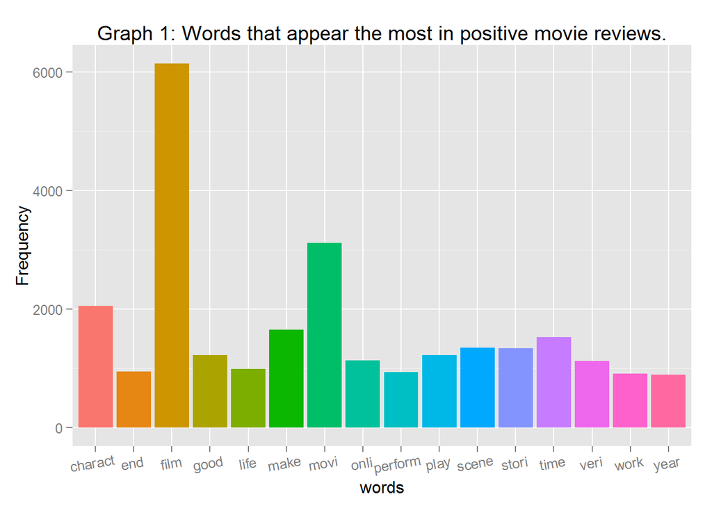

```r
pos_freq900 <- subset(pos_words_freq, freq >= 900)

ggplot(data = pos_freq900, aes(x= words, y =freq, fill=words)) + geom_bar(stat="identity")  + theme(legend.position="none") + theme(axis.text.x  = element_text(angle=10, vjust=.9, hjust=.6)) + ggtitle("Graph 1: Words that appear the most in positive movie reviews.") + ylab("Frequency")
```

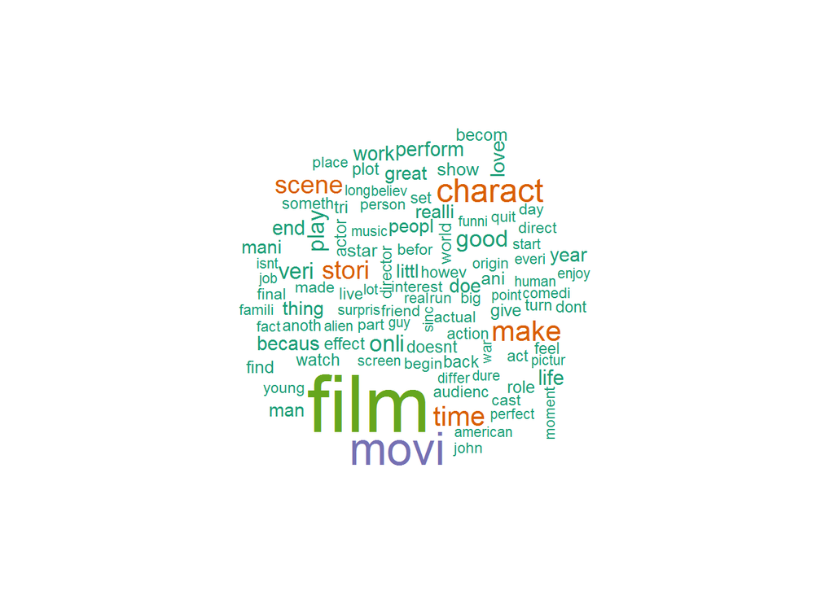

```r
dtm2 <- as.matrix (common_terms)
freq <- colSums(dtm2)

freq <- sort(freq, decreasing = TRUE)
words <-names(freq)

wordcloud(words[1:100], freq [1:100], colors=brewer.pal(5, "Dark2"))
```

UP

**We uploaded all the text files in the negative movie review folder to `r` by creating a path from our local working directory. Then we created a corpus for negative movie reviews, using the `tm` package. Using the `tm` and `SnowballC` packages we transformed and tidied the corpus.**

```r
neg <- file.path(getwd(), "review_polarity/txt_sentoken/neg")
head(neg)
```

```
## [1] "C:/Users/Nabila/Documents/CLASS  IS 607/Assignment 11-12/review_polarity/txt_sentoken/neg"
```

```r
head(dir(neg))
```

```
## [1] "cv000_29416.txt" "cv001_19502.txt" "cv002_17424.txt" "cv003_12683.txt"
## [5] "cv004_12641.txt" "cv005_29357.txt"
```

```r
neg_corpus <- Corpus(DirSource(neg))

funs <- list(stripWhitespace, removePunctuation, removeNumbers, content_transformer(tolower), simple_words, stemDocument, PlainTextDocument)
neg_corpus <- tm_map(neg_corpus, FUN = tm_reduce, tmFuns = funs)

#inspect (neg_corpus [2])
writeLines(as.character(neg_corpus[2]))
```

[output not shown]

UP

**Creating a data frame with the most occurring words in negative reviews.**

```r
common_terms2 <- DocumentTermMatrix(neg_corpus)
common_terms2
```

```
## <<DocumentTermMatrix (documents: 1000, terms: 20111)>>
## Non-/sparse entries: 208766/19902234
## Sparsity           : 99%
## Maximal term length: 53
## Weighting          : term frequency (tf)
```

```r
word_freq_neg <- sort(colSums(as.table(common_terms2)), decreasing=FALSE)


neg_word_freq <- data.frame(word=names(word_freq_neg), freq=word_freq_neg)
row.names(neg_word_freq) <- NULL

tail(neg_word_freq)
```

```
##          word freq
## 20106    onli 1349
## 20107    time 1377
## 20108    make 1526
## 20109 charact 1798
## 20110    movi 3760
## 20111    film 4971
```

UP

**Creating visual for negative movie review. Using `ggplot2`, `wordcloud` and `RColorBrewer` packages we created a histogram with most frequent words (frequency >= 900) and a word cloud with the most frequent (top 100) words.**

```r
findAssocs(common_terms2, c("flim", "story"), 0.5)
```

```
## $flim
## numeric(0)
##
## $story
##         exotic    gradeschool       halfstat        heroine        inveigl
##           0.71           0.71           0.71           0.71           0.71
##        rangoon    screenarkin westernerperil           mors          arkin
##           0.71           0.71           0.71           0.69           0.67
##            doo
##           0.62
```

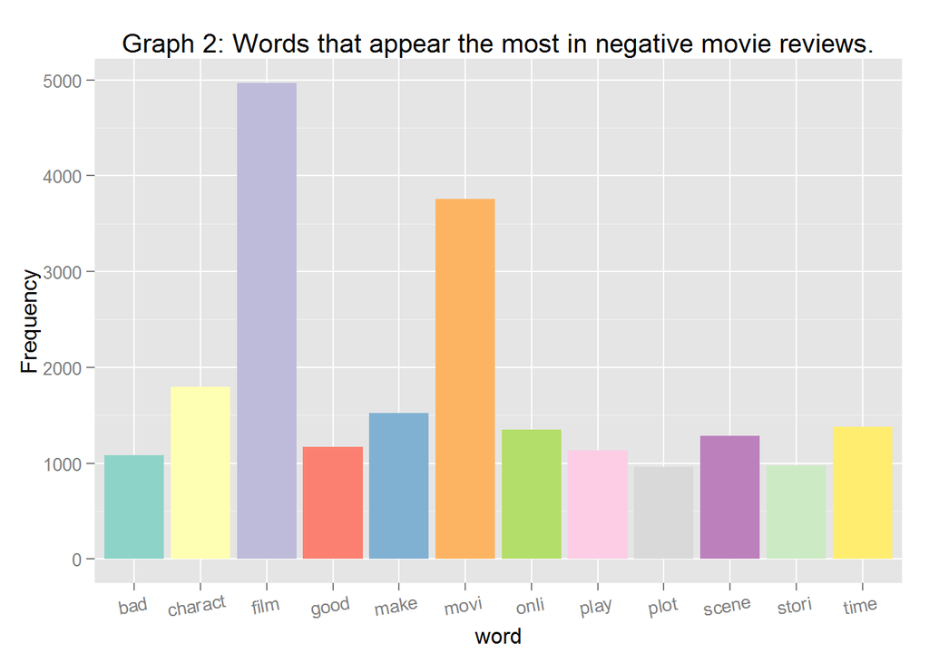

```r
neg_freq900 <- subset(neg_word_freq, freq >= 900)

ggplot(data =  neg_freq900, aes(x= word, y =freq, fill=word)) + geom_bar(stat="identity") + scale_fill_brewer(palette = "Set3") + theme(legend.position="none") + theme(axis.text.x  = element_text(angle=10, vjust=.9, hjust=.6)) + ggtitle("Graph 2: Words that appear the most in negative movie reviews.") +ylab("Frequency")
```

```r
neg_freq100 <- subset(neg_word_freq, freq >= 100)

neg_freq500 <- subset(neg_word_freq, freq >= 500)
head(neg_freq500, 10)
```

```
##           word freq
## 20063   script  504
## 20064    minut  506
## 20065   actual  508
## 20066     role  508
## 20067    becom  514
## 20068      guy  516
## 20069   someth  526
## 20070     find  528
## 20071  audienc  533
## 20072 interest  536
```

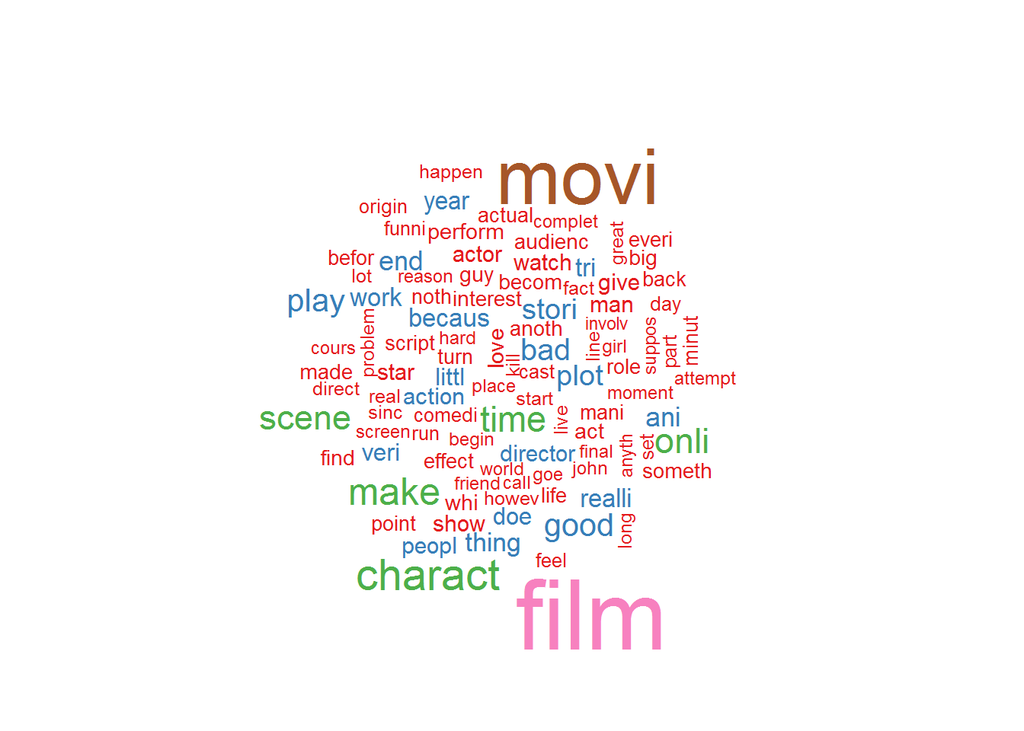

```r
wordcloud(neg_freq100$word, neg_freq100$freq, max.words=100, colors=brewer.pal(8, "Set1"))
```

UP

**Creating words matrix associated with positive or negatives reviews**

step1. transform the most frequently appeared positive words, over 900 times, into a data frame format.

step2. transform the most frequently appeared negative words, over 900 times, into a data frame format.

Step3. Adjust the dimension of the data frames for both the negative and positive reviews.

Step4. Combined both data frames to create “movies review matrix”

```r
dtm <- t(common_terms)
class(dtm)
```

```
## [1] "TermDocumentMatrix"    "simple_triplet_matrix"
```

```r
dtm3 <- as.big.matrix(x=as.matrix(dtm))
str(dtm3)
```

```
## Formal class 'big.matrix' [package "bigmemory"] with 1 slot
##   ..@ address:<externalptr>
```

```r
M <- as.matrix(dtm3)


write.csv(pos_freq900, file= "csvpos.csv")
pos_key <- read.csv("csvpos.csv", stringsAsFactors = FALSE)
pos_key1 <- pos_key$words

M2 <- t(M)

M3<- M2[,colnames(M2) %in% pos_key1]
head(M3)
```

```
##              charact end film good life make movi onli perform play scene
## character(0)       0   3    6    2    0    2    0    0       1    0     1
## character(0)       1   0    8    1    2    1    2    0       1    3     0
## character(0)       0   1    2    1    0    2    2    2       0    2     1
## character(0)       0   0    7    0    0    3    5    3       5    2     1
## character(0)       2   1    3    0    0    0    6    1       0    2     2
## character(0)       1   1    1    3    4    0    0    0       2    0     0
##              stori time veri work year
## character(0)     0    2    1    0    0
## character(0)     1    0    0    0    1
## character(0)     1    2    1    2    2
## character(0)     2    4    0    2    1
## character(0)     0    0    0    0    0
## character(0)     7    3    0    1    1
```

```r
M4 <- as.data.frame(M3)
head(M4)
```

```
##                charact end film good life make movi onli perform play
## character(0)         0   3    6    2    0    2    0    0       1    0
## character(0).1       1   0    8    1    2    1    2    0       1    3
## character(0).2       0   1    2    1    0    2    2    2       0    2
## character(0).3       0   0    7    0    0    3    5    3       5    2
## character(0).4       2   1    3    0    0    0    6    1       0    2
## character(0).5       1   1    1    3    4    0    0    0       2    0
##                scene stori time veri work year
## character(0)       1     0    2    1    0    0
## character(0).1     0     1    0    0    0    1
## character(0).2     1     1    2    1    2    2
## character(0).3     1     2    4    0    2    1
## character(0).4     2     0    0    0    0    0
## character(0).5     0     7    3    0    1    1
```

```r
M4$class <- "Positive"

write.csv(neg_freq900, file = "csvtest.csv")
negkey <- read.csv("csvtest.csv", stringsAsFactors = FALSE)
negkey
```

```
##        X    word freq
## 1  20100    plot  962
## 2  20101   stori  977
## 3  20102     bad 1087
## 4  20103    play 1137
## 5  20104    good 1169
## 6  20105   scene 1289
## 7  20106    onli 1349
## 8  20107    time 1377
## 9  20108    make 1526
## 10 20109 charact 1798
## 11 20110    movi 3760
## 12 20111    film 4971
```

```r
keyword3<- negkey$word
str(keyword3)
```

```
##  chr [1:12] "plot" "stori" "bad" "play" "good" "scene" ...
```

```r
neg_dtm <- t(common_terms2)
dtm4 <- as.big.matrix(x=as.matrix(neg_dtm))
str(dtm4)
```

```
## Formal class 'big.matrix' [package "bigmemory"] with 1 slot
##   ..@ address:<externalptr>
```

```r
M5 <- as.matrix(dtm4)

M6 <- t(M5)
M7 <- M6[,colnames(M6) %in% keyword3]
M8 <- as.data.frame(M7)
M8$class <- "Negative"


colnames(M8)
```

```
##  [1] "bad"     "charact" "film"    "good"    "make"    "movi"    "onli"
##  [8] "play"    "plot"    "scene"   "stori"   "time"    "class"
```

```r
colnames(M4)
```

```
##  [1] "charact" "end"     "film"    "good"    "life"    "make"    "movi"
##  [8] "onli"    "perform" "play"    "scene"   "stori"   "time"    "veri"
## [15] "work"    "year"    "class"
```

```r
M4$bad <- 0
M4$film <- 0
M4$plot <- 0

M8$end<-0
M8$life<-0
M8$perform<-0
M8$veri<- 0
M8$work<-0
M8$year <- 0

totalM <- rbind.data.frame(M4, M8)

totalM [995:1020,4:17]
```

```
##                  good life make movi onli perform play scene stori time
## character(0)994     5    1    0    4    0       3    0     0     0    0
## character(0)995     4    0    2   22    1       1    5     0     0    4
## character(0)996     0    0    0    0    0       0    0     2     2    1
## character(0)997     0    0    4    5    2       1    3     4     2    2
## character(0)998     1    0    1    3    0       2    1     0     0    2
## character(0)999     0    7    0    8    0       1    0     4     4    0
## character(0)1000    2    0    7    7    1       0    1     2     0    0
## character(0)1001    1    0    0    5    0       0    0     0     1    1
## character(0)1002    0    0    2    3    2       0    1     0     0    2
## character(0)1003    1    0    0    0    2       0    0     1     1    1
## character(0)1004    1    0    0    3    2       0    1     1     3    2
## character(0)1005    2    0    3    2    0       0    0     4     2    3
## character(0)1006    1    0    2    1    2       0    2     0     0    2
## character(0)1007    0    0    0    7    1       0    4     2     0    1
## character(0)1008    0    0    2    3    3       0    2     0     1    4
## character(0)1009    0    0    0    8    1       0    1     2     1    3
## character(0)1010    0    0    2    4    2       0    2     1     0    1
## character(0)1011    1    0    0    5    2       0    4     1     0    2
## character(0)1012    0    0    0    0    2       0    1     2     1    1
## character(0)1013    0    0    3   27    3       0    6     7     2    0
## character(0)1014    0    0    2    1    0       0    1     2     0    3
## character(0)1015    0    0    1    5    1       0    0     0     1    1
## character(0)1016    2    0    0   16    4       0    1     0     1    1
## character(0)1017    0    0    0   10    1       0    0     1     2    2
## character(0)1018    1    0    3    3    1       0    1     0     0    1
## character(0)1019    0    0    0    4    3       0    0     2     2    0
##                  veri work year    class
## character(0)994     1    1    0 Positive
## character(0)995     6    0    3 Positive
## character(0)996     1    1    0 Positive
## character(0)997     0    0    0 Positive
## character(0)998     0    1    1 Positive
## character(0)999     0    1    0 Positive
## character(0)1000    0    0    0 Negative
## character(0)1001    0    0    0 Negative
## character(0)1002    0    0    0 Negative
## character(0)1003    0    0    0 Negative
## character(0)1004    0    0    0 Negative
## character(0)1005    0    0    0 Negative
## character(0)1006    0    0    0 Negative
## character(0)1007    0    0    0 Negative
## character(0)1008    0    0    0 Negative
## character(0)1009    0    0    0 Negative
## character(0)1010    0    0    0 Negative
## character(0)1011    0    0    0 Negative
## character(0)1012    0    0    0 Negative
## character(0)1013    0    0    0 Negative
## character(0)1014    0    0    0 Negative
## character(0)1015    0    0    0 Negative
## character(0)1016    0    0    0 Negative
## character(0)1017    0    0    0 Negative
## character(0)1018    0    0    0 Negative
## character(0)1019    0    0    0 Negative
```

**Writting a CSV file with the movie review matrix.**

```r
write.csv(totalM, file = "C:/Users/Nabila/Documents/GitHub/Class-IS607/Week 11-12 Assignment/movies_review_matrix.csv")
```

UP

**Testing with random Forest model**

Step1.clean up the row names of the data frame.

Step2. Change the data frame column, “class”, to factor from character.

Step3. Run Random Forest package and produce “confusion matrix” & important variables association.

```r
row.names(totalM) <-NULL
WM <- totalM

str(WM)
```

```
## 'data.frame':    2000 obs. of  19 variables:
##  $ charact: num  0 1 0 0 2 1 3 4 1 1 ...
##  $ end    : num  3 0 1 0 1 1 1 0 0 0 ...
##  $ film   : num  0 0 0 0 0 0 0 0 0 0 ...
##  $ good   : num  2 1 1 0 0 3 2 1 0 0 ...
##  $ life   : num  0 2 0 0 0 4 0 1 2 0 ...
##  $ make   : num  2 1 2 3 0 0 7 3 2 0 ...
##  $ movi   : num  0 2 2 5 6 0 4 2 0 0 ...
##  $ onli   : num  0 0 2 3 1 0 2 0 0 0 ...
##  $ perform: num  1 1 0 5 0 2 4 4 1 0 ...
##  $ play   : num  0 3 2 2 2 0 2 1 1 0 ...
##  $ scene  : num  1 0 1 1 2 0 2 0 1 1 ...
##  $ stori  : num  0 1 1 2 0 7 2 1 1 1 ...
##  $ time   : num  2 0 2 4 0 3 1 2 0 1 ...
##  $ veri   : num  1 0 1 0 0 0 4 0 0 0 ...
##  $ work   : num  0 0 2 2 0 1 2 0 0 1 ...
##  $ year   : num  0 1 2 1 0 1 3 1 0 0 ...
##  $ class  : chr  "Positive" "Positive" "Positive" "Positive" ...
##  $ bad    : num  0 0 0 0 0 0 0 0 0 0 ...
##  $ plot   : num  0 0 0 0 0 0 0 0 0 0 ...
```

```r
#change the catagorization to factor type
WM$class <- factor(WM$class)


rf = randomForest(class ~ ., data = WM, mtry =4 , ntree = 400)
rf
```

```
##
## Call:
##  randomForest(formula = class ~ ., data = WM, mtry = 4, ntree = 400)
##                Type of random forest: classification
##                      Number of trees: 400
## No. of variables tried at each split: 4
##
##         OOB estimate of  error rate: 1.45%
## Confusion matrix:
##          Negative Positive class.error
## Negative      986       14       0.014
## Positive       15      985       0.015
```

```r
rf$confusion
```

```
##          Negative Positive class.error
## Negative      986       14       0.014
## Positive       15      985       0.015
```

```r
rf$importance
```

```
##         MeanDecreaseGini
## charact         4.175632
## end            94.193930
## film          354.549988
## good            4.194192
## life           38.501848
## make            4.062108
## movi            8.773636
## onli            4.244540
## perform        69.468478
## play            3.943697
## scene           4.706530
## stori           3.565164
## time            4.610355
## veri           91.417814
## work           59.106525
## year           76.457462
## bad            79.199003
## plot           85.699544
```

UP